# P4

Heather Hawkins

2023-03-05

## Loading Packages

```r
library(tidyverse)
```

```r
library(ggeasy)
library(ggplot2)
library(skimr)
library(haven)
```

In this piece, I decided to play around with a dataset that EJ had, This dataset contains a lot of social psychology information from past students, for example, the satisfaction with life, Fear of Negative Evaluation, and Narcissim scales are included

```r
library(haven)
OnlinePsychologySurveyData <- read_sav("~/Documents/GitHub/Project-1/Porfolio 4/OnlinePsychologySurveyData.sav")
View(OnlinePsychologySurveyData)

OPSD <- OnlinePsychologySurveyData
```

Since this data has been worked on in SPSS, I’m only going to play around with plots, filters, and results.

In this profolio I will focus on the scales of Need For Cognition, the Rosenberg Self-Esteem Scale, and the Narcissism / Narcissistic Personality Inventory

First, lets see if there are any simple results

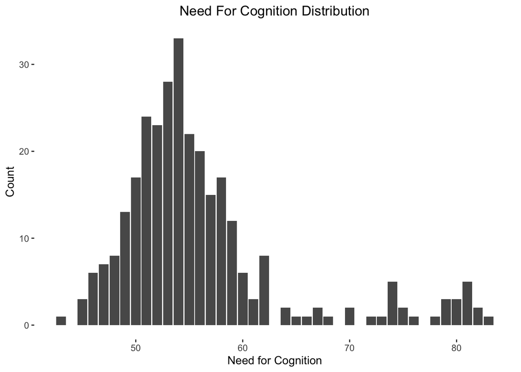

```r
#Lets start with Need for Cognition
OPSD %>%
  ggplot(OPSD, mapping = aes(x = NFCTot))+geom_bar()+labs (x= "Need for Cognition", y= "Count")+labs(title= "Need For Cognition Distribution")+ theme(panel.background = element_blank())+ggeasy::easy_center_title()
```

Need for Cognition seems to be kind of positively skewed,

There are a couple of people with high need for cognition, but there are many people between low and average need for cognition

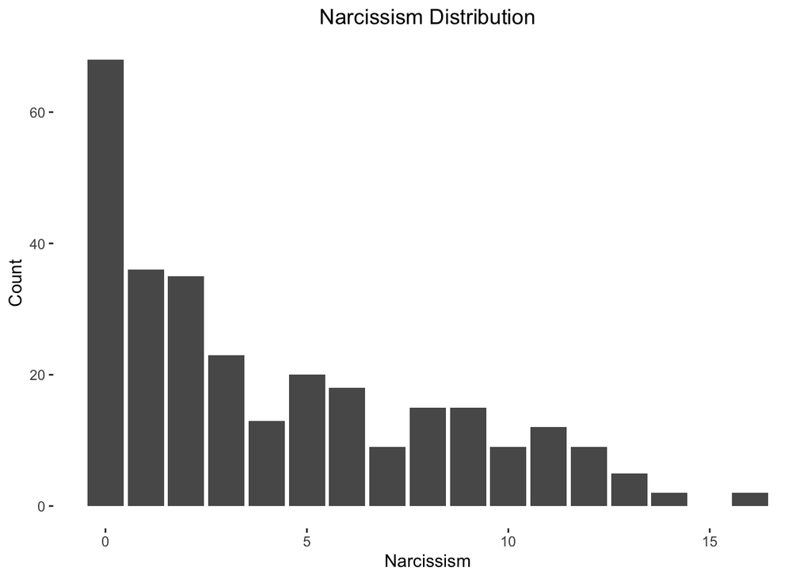

```r
#Now Narcissim
OPSD %>%
  ggplot(OPSD, mapping = aes(x= NPITot))+geom_bar()+labs (x= "Narcissism", y= "Count")+labs(title= "Narcissism Distribution")+ theme(panel.background = element_blank())+ggeasy::easy_center_title()
```

Narcissism seems to be highly positively skewed,

There are only a few people with high narcissism, and many people with low narcissism

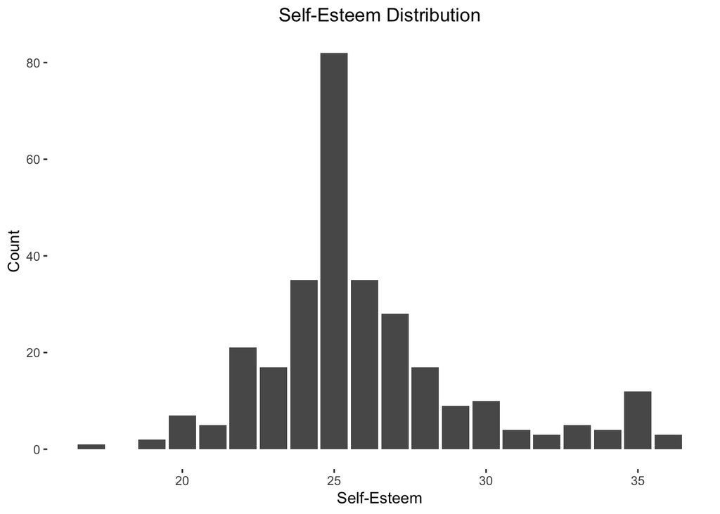

```r
#Finally, Self-Esteem
OPSD %>%
  ggplot(OPSD, mapping = aes(x = RSETot))+geom_bar()+labs (x= "Self-Esteem", y= "Count")+labs(title= "Self-Esteem Distribution")+ theme(panel.background = element_blank())+ggeasy::easy_center_title()
```

This one is fairly-normally distributed. —————-

Now lets see if there are any simple interactions

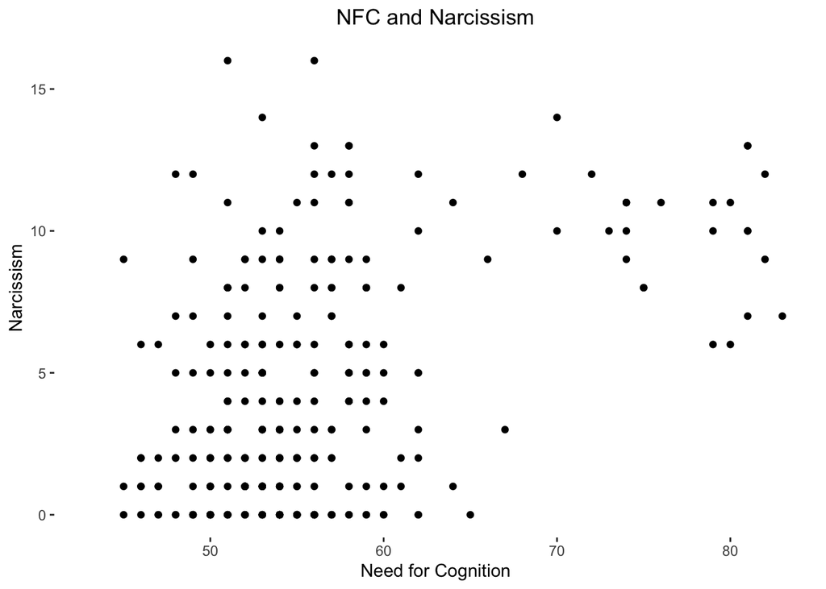

```r
#Lets start with Need for Cognition and Narcissim
OPSD %>%
  ggplot(OPSD, mapping = aes(x = NFCTot, y= NPITot))+geom_point()+labs (x= "Need for Cognition", y= "Narcissism")+labs(title= "NFC and Narcissism")+ theme(panel.background = element_blank())+ggeasy::easy_center_title()
```

There doesn’t seem to be anything crazy, although there are alot of people that are low in Need for Cognition ———————————–

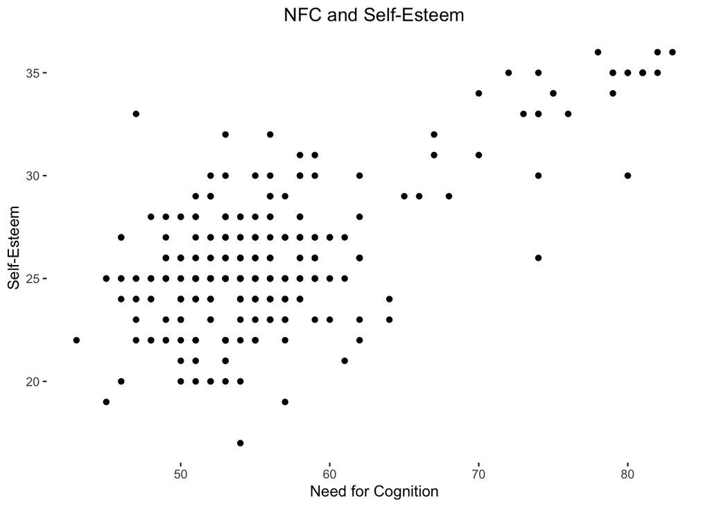

```r
#Now lets do Need for Cognition and the Rosenberg Self-Esteem Scale
OPSD %>%
  ggplot(OPSD, mapping = aes(x = NFCTot, y= RSETot))+geom_point()+labs (x= "Need for Cognition", y= "Self-Esteem")+labs(title= "NFC and Self-Esteem")+ theme(panel.background = element_blank())+ggeasy::easy_center_title()
```

Woah! there seems to be a linear regression!! The higher the need for cognition, the higher self-esteem seems to be! ————————————

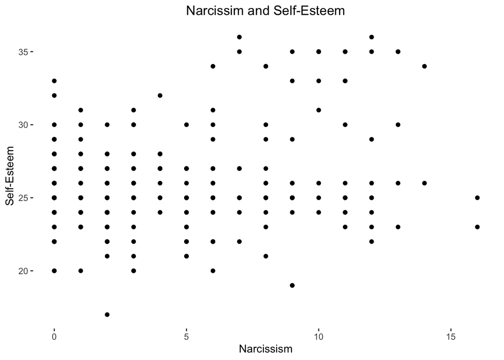

```r
#Finally lets do the Rosenberg Self-Esteem Scale and Narcissim
OPSD %>%
  ggplot(OPSD, mapping = aes(x = NPITot, y= RSETot))+geom_point()+labs (x= "Narcissism", y= "Self-Esteem")+labs(title= "Narcissim and Self-Esteem")+ theme(panel.background = element_blank())+ggeasy::easy_center_title()
```

## Yeah…. it’s all over the place. I thought there would be some corrleation (e.g., high self-esteem and high narcissim), but I guess not in this sample.

Now, lets look at all three at the same time

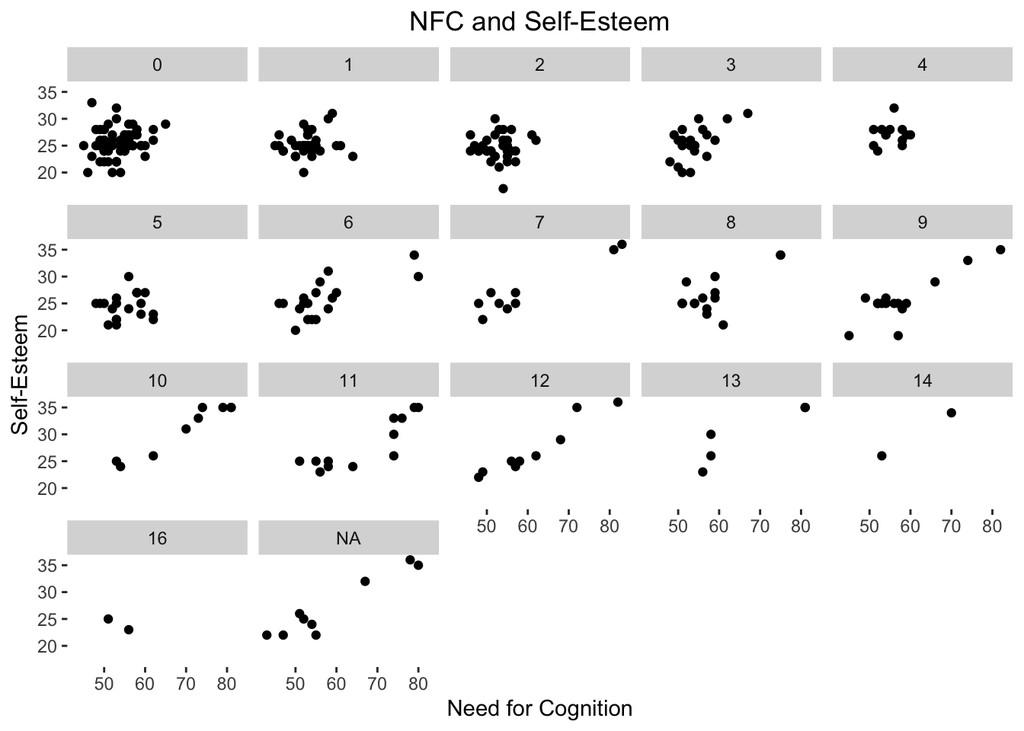

```r
#Need for Cognition, the Rosenberg Self-Esteem Scale and the
OPSD %>%
  ggplot(OPSD, mapping = aes(x = NFCTot, y= RSETot))+geom_point()+ facet_wrap(~NPITot) + labs (x= "Need for Cognition", y= "Self-Esteem")+labs(title= "NFC and Self-Esteem")+ theme(panel.background = element_blank())+ggeasy::easy_center_title()
```

Okay, bad idea, I cant read that….

Lets try faceting by something else

[figure not shown]

```r
#Need for Cognition, the Rosenberg Self-Esteem Scale and the
OPSD %>%
  ggplot(OPSD, mapping = aes(x = NPITot, y= RSETot))+geom_point()+ facet_wrap(~NFCTot) + labs (x= "Need for Cognition", y= "Self-Esteem")+labs(title= "NFC and Self-Esteem")+ theme(panel.background = element_blank())+ggeasy::easy_center_title()
```

Yeah this is also terrible. Maybe Facet wrap isnt our friend. Lets do fill.

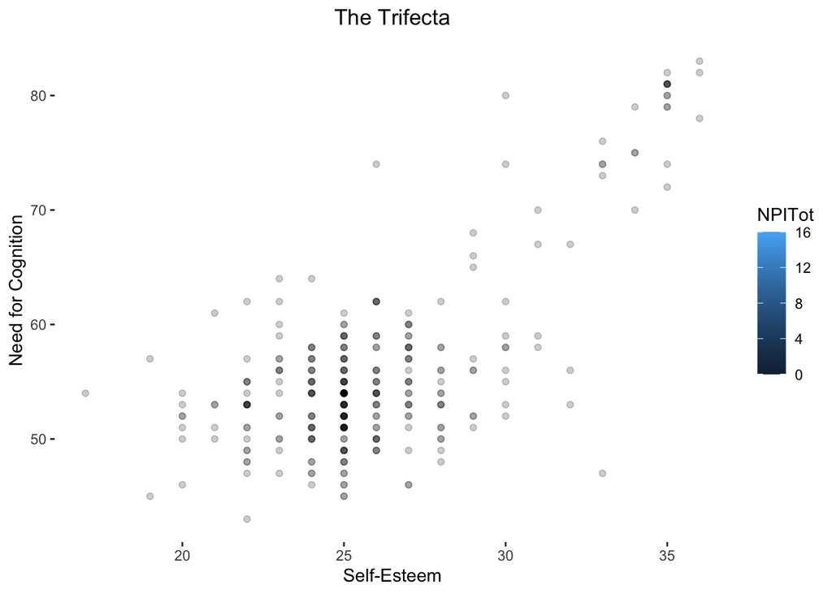

```r
#Need for Cognition, the Rosenberg Self-Esteem Scale and the
OPSD %>%
  ggplot(OPSD, mapping = aes(x = RSETot, y= NFCTot, fill= NPITot))+ geom_point(alpha = 0.2) + labs (x= "Self-Esteem", y= "Need for Cognition")+labs(title= "The Trifecta")+ theme(panel.background = element_blank())+ggeasy::easy_center_title()
```